# Risk Analyses and Prediction of US Adult Chronic Diseases

Final Project of Data Science for Biomedical Informatics (BMIN503/EPID600) Instructor: Blanca Himes Nianfu Song

# 1. Introduction

## 1.1. Overview

The goal of my final project is to use survey data to analyze health related factors and predict potential risk of diseases. The National Health Interview Data are analyzed with logistic, rare event logistic and machine learning methods to predict risks of 16 types of comman diseases. Cross validation is applied to evaluate the power of prediction of estimated models.

## 1.2. Aims of the project

Chronic diseases such as cancer, lung disease, and stroke have been major health concerns and reasons of death in the U.S. Risk evaluation of these diseases can lead to preventional treatments or lifestyle changes that help patients survive and improve quality of life. The National Health Interview database enables us to use analytical tools to estimate the associations between lifestyles and health and predict the risks of many types of diseases with only simple interview answers. The risks of diseases could be estimated before any labs and clinical visits. When integrated into web tools, anybody can do the predictions by answering simple questions about themselves.

# 2. Method and data

The data from National Health Interview Survey [NHIS 2018](https://www.cdc.gov/nchs/nhis/data-questionnaires-documentation.htm) are analyzed first by plots, tables, and maps, then by logistic and random forest models before rare event logistic models are estimated. The estimated results are represented in ROCs and heatmaps specifically designed for this project using truncated and signed log-transformed p-values that are less than 0.05.

## 2.1. Data Downloading, Dimension, IDs, and Relations between Data Tables

Please read comments to help understand the code. Some comments, however, are inactivated code lines for program testing and data examination.

```r
temp <- tempfile()
download.file("ftp://ftp.cdc.gov/pub/Health_Statistics/NCHS/Datasets/NHIS/2018/househldcsv.zip", temp)
hshld <- read.csv(unz(temp, "househld.csv"))
download.file("ftp://ftp.cdc.gov/pub/Health_Statistics/NCHS/Datasets/NHIS/2018/familyxxcsv.zip", temp)
fmly <- read.csv(unz(temp, "familyxx.csv"))
download.file("ftp://ftp.cdc.gov/pub/Health_Statistics/NCHS/Datasets/NHIS/2018/personsxcsv.zip", temp)
prsn <- read.csv(unz(temp, "personsx.csv"))
download.file("ftp://ftp.cdc.gov/pub/Health_Statistics/NCHS/Datasets/NHIS/2018/samadultcsv.zip", temp)
adlt <- read.csv(unz(temp, "samadult.csv"))
download.file("ftp://ftp.cdc.gov/pub/Health_Statistics/NCHS/Datasets/NHIS/2018/samchildcsv.zip", temp)
chldrn <- read.csv(unz(temp, "samchild.csv"))
unlink(temp)

#dim(hshld) ## 46500x17
#dim(fmly) ## 30307x127
#dim(prsn) ## 72831x602
#dim(adlt) ## 25417x742
#dim(chldrn) ## 8269x158

# data table number of rows and columns
NHIStables <- data.frame(c("Household", "Family", "Persons", "Adults", "Children"),
                        rbind(dim(hshld), dim(fmly), dim(prsn), dim(adlt), dim(chldrn)))
names(NHIStables) <- c("dataName", "rows", "columns")
NHIStables
```

```
##    dataName  rows columns
## 1 Household 46500      17
## 2    Family 30309     127
## 3   Persons 72831     602
## 4    Adults 25417     742
## 5  Children  8269     158
```

```r
#common columns compared with family table
com.hs_fm <- na.omit(match(names(hshld), names(fmly))) #4:6
names(fmly[,com.hs_fm])
```

```
## [1] "RECTYPE" "SRVY_YR" "HHX"
```

```r
com.ps_fm <- na.omit(match(names(prsn), names(fmly)))  #3:6
names(fmly[,com.ps_fm])
```

```
## [1] "FMX"     "RECTYPE" "SRVY_YR" "HHX"
```

```r
com.ad_fm <- na.omit(match(names(adlt), names(fmly)) ) #3:6
names(fmly[,com.ad_fm])
```

```
## [1] "FMX"     "HHX"     "RECTYPE" "SRVY_YR"
```

```r
com.ch_fm <- na.omit(match(names(chldrn), names(fmly)))  #3:6
names(chldrn[,com.ch_fm])
```

```
## [1] "SEX"      "FMX"      "HISPAN_I" "MRACRPI2"
```

```r
#children and adults
com.ch_ad <- na.omit( match(names(chldrn), names(adlt)))
length(com.ch_ad) # 158 columns are all in adult
```

```
## [1] 16
```

```r
com.ad_ch <- na.omit( match(names(adlt), names(chldrn)))
length(com.ad_ch) # 158 columns are all in adult
```

```
## [1] 16
```

```r
#person and adults
com.pr_ad <- na.omit( match(names(prsn), names(adlt)))
length(com.pr_ad) # 158 columns are all in adult
```

```
## [1] 17
```

```r
sort(names(adlt[,com.pr_ad]))
```

```
##  [1] "AGE_P"    "FMX"      "FPX"      "HHX"      "HISPAN_I" "INTV_MON" "INTV_QRT" "MRACBPI2" "MRACRPI2"
## [10] "PPSU"     "PSTRAT"   "R_MARITL" "RACERPI2" "RECTYPE"  "REGION"   "SEX"      "SRVY_YR"
```

```r
com.ad_pr <- na.omit( match(names(adlt), names(prsn)))
length(com.ad_pr) # 158 columns are all in adult
```

```
## [1] 17
```

```r
sort(names(prsn[, com.ad_pr]))
```

```
##  [1] "AGE_P"    "FMX"      "FPX"      "HHX"      "HISPAN_I" "INTV_MON" "INTV_QRT" "MRACBPI2" "MRACRPI2"
## [10] "PPSU"     "PSTRAT"   "R_MARITL" "RACERPI2" "RECTYPE"  "REGION"   "SEX"      "SRVY_YR"
```

```r
## common names
head(hshld[, names(fmly[, c(4:6)])])
```

```
##   RECTYPE SRVY_YR HHX
## 1      10    2018   1
## 2      10    2018   3
## 3      10    2018   4
## 4      10    2018   6
## 5      10    2018   8
## 6      10    2018   9
```

```r
head(prsn[, names(fmly[, c(3:6)])])
```

```
##   FMX RECTYPE SRVY_YR HHX
## 1   1      20    2018   1
## 2   1      20    2018   4
## 3   1      20    2018   4
## 4   1      20    2018   4
## 5   1      20    2018   6
## 6   1      20    2018   6
```

```r
head(adlt[, names(fmly[, c(3:6)])])
```

```
##   FMX RECTYPE SRVY_YR HHX
## 1   1      30    2018   1
## 2   1      30    2018   6
## 3   1      30    2018   8
## 4   1      30    2018   9
## 5   1      30    2018  10
## 6   1      30    2018  13
```

```r
#head(chldrn[, names(fmly[, c(3:6)])])
##uniqueness of ids
dim(distinct(adlt[, c("FMX", "HHX")])) # unique ID, FPX is a number of head of Household
```

```
## [1] 25417     2
```

```r
dim(adlt)
```

```
## [1] 25417   742
```

```r
dim(distinct(prsn[, c("FMX","HHX", "FPX")])) # unique ID
```

```
## [1] 72831     3
```

```r
dim(prsn)
```

```
## [1] 72831   602
```

```r
dim(distinct(fmly[, c("FMX","HHX")])) # unique ID
```

```
## [1] 30309     2
```

```r
dim(fmly)
```

```
## [1] 30309   127
```

```r
##join to construction data of unique variables. persons<adults<household<family
Allxx <- left_join(prsn, adlt, by=names(adlt[, com.pr_ad])[-11]) %>%
  left_join(hshld, by ="HHX") %>%
   left_join(fmly, by =c("HHX", "FMX") )
names(Allxx)
```

[output not shown]

[output cut: 195 more lines]

```r
#View(xx)
```

# 2.2. Variable Selection and Transformation

Potential response variables are selected diseases such as cancers and 15 other types of chronic diseases. All demographic, activities, smoking, drinking, and other lifestyle related factors are included as potential predictors. The unknown, not answered, and not applicable values are change into NA values. All categorical and some continuous variables such as first smoking age and hours of sleep are transformed into categorical variables to simplify estimation for logistic models by constructing only linear link functions in the logistic model. Such a categoricalization of continuous variables is an approximation to a nonlinear link function. All data categories are labeled to reduce errors in coding. Consistency of transformation is checked against their corresponding original data. Thus, you may expect to see some examination code lines for consistency. The three columns of data for vigorous, strength, and moderate physical activities are combined into a categorical variable to measure different types of activity. Age and BMI are the only continuous variables included in the estimation. They are kept as continuous variables just to keep the diversity of the model and see if the code may work better or worse with them. For details of the data transformations, please read the comments in the code chunks.

```r
#family table
fm <- fmly %>%
  select(HHX, FMX, FM_SIZE)
#person table
ps <- ps0 <- prsn %>%
  select(HHX, FMX, FPX, REGION, REGIONBR,
         HISCODI3, FSPOUS2, FMOTHER1, FFATHER1, MOM_ED, DAD_ED,

         LADURA1,  LADURA2,  LADURA3, LADURA4, LADURA7,LADURA8, LADURA9, LADURA10,
         LADURA11,  LADURA12,  LADURA18, LADURA21, LADURA28,  LADURA29, LDURA14A,

         LADURB1, LADURB2, LADURB3, LADURB4, LADURB7, LADURB8,  LADURB9, LADURB10,
         LADURB11, LADURB12, LADURB18, LADURB21, LADURB28, LADURB29, LDURB14A,
         PHSTAT, WRKLYR1, WRKFTALL)
# Check names
# names(ps0)[12:26]
# names(ps0)[27:41]
#replace missings in with 0 where no diseases are blank
ps[, c(12:41)] <- replace(ps0[, c(12:41)], is.na(ps0[, c(12:41)]), -1)   ##missing cells are 0
# 97,98,99, 7,8,9 cases for some variables
ps[, c(12:26)] <- replace(ps[, c(12:26)], (ps[, c(12:26)] %in% c(96,97, 98,99)), NA)   ##group into 99
ps[, c(27:41)] <- replace(ps[,c (27:41)], (ps[, c(27:41)] %in% c(7, 8, 9)), NA)   ##group into 99
#table(ps[,27], exclude = NULL)
#adult table
ad <- ad0 <- adlt %>%
  select(HHX, FMX, FPX, SEX, AGE_P, MRACRPI2, R_MARITL, PAR_STAT, INDSTRN1, WRKCATA,
         ALDURA1, ALDURA2, ALDURA3, ALDURA4, ALDURA7,ALDURA8, ALDURA9, ALDURA10,
         ALDURA11, ALDURA12, ALDURA18, ALDURA21, ALDURA28,  ALDURA29, ADURA14A,
         ALDURB1, ALDURB2, ALDURB3, ALDURB4, ALDURB7,   ALDURB8,  ALDURB9,  ALDURB10,
         ALDURB11, ALDURB12, ALDURB18, ALDURB21, ALDURB28, ALDURB29, ADURB14A, LIVEV,
         SMKEV, SMKREG, SMKNOW, SMKSTAT2, VIGFREQW, MODFREQW, STRFREQW, ALCSTAT ,AHEIGHT, AWEIGHTP, BMI,
         ASISLEEP,AASSTILL )
# Check names
#names(ad0)[11:25]
#names(ad0)[26:41]
#replace 7,8,9,97, 98, 99 for refuse, uncertain, and unknown,
ad[, c(11:41)] <- replace(ad0[, c(11:41)], is.na(ad0[,c(11:41)]), -1)   ##missing cells are 0
ad[, c("SMKEV")] <- replace(ad[, c("SMKEV")],(ad[, c("SMKEV")] %in% c(7, 8, 9)), NA)   #### above 99.5
ad[, c("SMKREG")] <- replace(ad[, c("SMKREG")],(ad[, c("SMKREG")] %in% c(96, 97, 98, 99)), NA)   #### above 99.5
ad[, c("SMKNOW")] <- replace(ad[, c("SMKSTAT2")],(ad[, c("SMKSTAT2")] %in% c(7, 8, 9)), NA)   #### above 99.5
ad[, c("SMKSTAT2")] <- replace(ad[, c("SMKSTAT2")],(ad[, c("SMKSTAT2")] %in% c(9)), NA)   #### above 99.5
ad[, c("ALCSTAT")] <- replace(ad[, c("ALCSTAT")],(ad[, c("ALCSTAT")] %in% c(9, 10)), NA)   ####Alcohol remove unknown frequency (very few)
ad[, c("ASISLEEP")] <- replace(ad[, c("ASISLEEP")], (ad[, c("ASISLEEP")] %in% c(97, 98, 99)), NA)   ####sleep hours
ad[, c("VIGFREQW")] <- replace(ad[, c("VIGFREQW")], (ad[, c("VIGFREQW")] %in% c(0)), 1)   #### vigorous excercise times 0=<1,
ad[, c("VIGFREQW")] <- replace(ad[, c("VIGFREQW")], (ad[, c("VIGFREQW")] %in% c(95, 96)), 0)   #### vigorous excercise 0 times
ad[, c("VIGFREQW")] <- replace(ad[, c("VIGFREQW")], (ad[, c("VIGFREQW")] %in% c(97, 98, 99)), NA)   ####
ad[, c("MODFREQW")] <- replace(ad[, c("MODFREQW")], (ad[, c("MODFREQW")] %in% c(0)), 1)   #### moderate excercise times 0=<1,
ad[, c("MODFREQW")] <- replace(ad[, c("MODFREQW")], (ad[, c("MODFREQW")] %in% c(95, 96)), 0)   #### moderate excercise 0 times
ad[, c("MODFREQW")] <- replace(ad[, c("MODFREQW")], (ad[, c("MODFREQW")] %in% c(97, 98, 99)), NA)   #### no moderate exc
ad[, c("STRFREQW")] <- replace(ad[, c("STRFREQW")], (ad[, c("STRFREQW")] %in% c(0)), 1)   #### strength excercise times 0=<1,
ad[, c("STRFREQW")] <- replace(ad[, c("STRFREQW")], (ad[, c("STRFREQW")] %in% c(95, 96)), 0)   #### strength excercise 0 times
ad[, c("STRFREQW")] <- replace(ad[, c("STRFREQW")], (ad[, c("STRFREQW")] %in% c(97, 98, 99)), NA)   #### no strength exc
ad[, c("AWEIGHTP")] <- replace(ad[, c("AWEIGHTP")], (ad[, c("AWEIGHTP")] %in% c(996, 997, 998, 999)), NA)   ####weight lbs.
ad[, c("AHEIGHT")] <- replace(ad[, c("AHEIGHT")],(ad[, c("AHEIGHT")] %in% c(96, 97, 98, 99)),NA)   ####height inch
ad[, c("BMI")] <- replace(ad[, c("BMI")], (ad[, c("BMI")] %in% c(9999)), NA)   ####sleep hours
ad[, c("BMI")] <- replace(ad[, c("BMI")], (ad[, c("BMI")] %in% c(9995)), 99.5)   #### above 99.5
ad[, c("PAR_STAT")] <- replace(ad[, c("PAR_STAT")],(ad[, c("PAR_STAT")] %in% c(9)), NA)   ####parents status
ad[, c("R_MARITL")] <- replace(ad[, c("R_MARITL")], (ad[, c("R_MARITL")] %in% c(9)), NA)   ####Marriage status
ad[, c("LIVEV")] <- replace(ad[, c("LIVEV")], (ad[, c("LIVEV")] %in% c(7, 8, 9)), NA)   ####liver condition
#add a flag for adult data rows to make it different from other data sources
ad$adult <- 1
# this columns is not included in the models because of BMI
ps[,c("FSPOUS2")] <- replace(ps[, c("FSPOUS2")], (ps[, c("FSPOUS2")] %in% c(98)) ,NA)   ####weight lbs.
#head(ad$adult)
#table(ad$R_MARITL)
# data are mostly integers now
# list of variables and number of na
mis.fm <- sapply(fm, function(x) sum(is.na(x)))
mis.ps <-sapply(ps, function(x) sum(is.na(x)))
mis.ad <- sapply(ad, function(x) sum(is.na(x)))
# MERGE and convert data into analyzable data types; Disease (nmaed dis?) are response variables for health status .
# 4 variables (smk, activ, sleep, and dis99) are tranformated with fct_rev() function to facilitate the default baseline as wanted.
hlth <- left_join(ps, ad, by=c('HHX', 'FMX', 'FPX')) %>%
  left_join(fm, by =c("HHX", "FMX") ) %>%
  mutate(sex=factor(SEX, levels=c(1, 2), labels=c("male", "female")),
         alc=factor(cut(ALCSTAT, breaks = c(0, 1, 5, 7,8), labels=c("Abstainer", "Former", "Light", "Heavier"))),
         smk=fct_rev(factor(SMKSTAT2, levels=c(1, 2, 3, 4), labels=c("Daily", "Some", "Former", "Never") )),
         age_smk=ifelse(smk=="Never", -5, SMKREG),
         age_smk=factor(cut(age_smk, breaks = c(-6, 0, 18, 100), labels=c("Never","6-18", "above19"), useNA='ifany' )),
         # three columns are merged into 1.
         activ=fct_rev(factor(ifelse(VIGFREQW >2, 1,
                              ifelse(STRFREQW>2, 2,
                              ifelse(MODFREQW>2, 3,
                              ifelse(VIGFREQW==0 & STRFREQW==0 & MODFREQW==0, 5, 4)))),
                              levels=c(1, 2, 3, 4, 5), labels = c("Vigorous","Strength","Moderate", "Some", "None"))),
         sleep=fct_rev(factor(cut(ASISLEEP, breaks = c(-1, 0, 4, 5, 6, 7, 24), useNA='ifany'),
                              labels = c("<=4 hrs", "5 hrs", "6 hrs", "7 hrs", ">7 hrs"))),
         fm_size=factor(cut(FM_SIZE, breaks = c(0, 1, 2, 4, 20), useNA='ifany' ),
                              labels = c("1 person", "2 persons", "3-4 persons", ">5 persons")),

         age=as.numeric(AGE_P),
         BMI=as.numeric(BMI)/100,

         region=factor(REGION, levels=c(1, 2, 3, 4), labels = c("Northeast", "Midwest", "South", "West")),
         race0= factor(HISCODI3,levels=c(1:5), labels = c("Hispanic", "White","Black", "Asian","Other")),
         race= factor(race0, levels = c("White", "Hispanic", "Black", "Asian","Other")),
         marriage = factor(cut(R_MARITL, breaks = c(0, 2, 6, 7, 8), useNA='ifany'), labels = c("married", "D/S/W", "Never", "Partner")),
         par_stat = factor(cut(PAR_STAT, breaks = c(0, 2, 3), useNA='ifany'), labels= c("Children", "No children")),

         dis1=factor(cut(ALDURB1, breaks =c(-1.1, -0.1, 4), useNA ='ifany'), labels = c("No vision disease", "Vision disease")),
         dis2=factor(cut(ALDURB2, breaks =c(-1.1, -0.1, 4), useNA ='ifany'), labels = c("No hearing disease", "Hearing disease")),
         dis3=factor(cut(ALDURB3, breaks =c(-1.1, -0.1, 4), useNA ='ifany'), labels = c("No arthritis disease", "Arthritis disease")),
         dis4=factor(cut(ALDURB4, breaks =c(-1.1, -0.1, 4), useNA ='ifany'), labels = c("No back or neck disease", "Back or neck")),
         dis7=factor(cut(ALDURB7, breaks =c(-1.1, -0.1, 4), useNA ='ifany'), labels = c("No heart disease", "Heart disease")),

         dis8=factor(cut(ALDURB8, breaks =c(-1.1, -0.1, 4), useNA ='ifany'), labels = c("No stroke disease", "Stroke")),
         dis9=factor(cut(ALDURB9, breaks =c(-1.1, -0.1, 4), useNA ='ifany'), labels = c("No hypertension disease", "Hypertension disease")),
         dis10=factor(cut(ALDURB10, breaks =c(-1.1, -0.1, 4), useNA ='ifany'), labels = c("No diabetes disease", "Diabetes disease")),
         dis11=factor(cut(ALDURB11, breaks =c(-1.1, -0.1, 4), useNA ='ifany'), labels = c("No lung or breathing disease", "Lung or breathing disease")),
         dis12=factor(cut(ALDURB12, breaks =c(-1.1, -0.1, 4), useNA ='ifany'), labels = c("No cancer disease", "Cancer disease")),

         dis14=factor(cut(ADURB14A, breaks =c(-1.1, -0.1, 4), useNA ='ifany'), labels = c("No mental retardation", "Mental retardation")),
         dis18=factor(cut(ALDURB18, breaks =c(-1.1, -0.1, 4), useNA ='ifany'), labels = c("No weight problem", "Weight problem")),
         dis21=factor(cut(ALDURB21, breaks =c(-1.1, -0.1, 4), useNA ='ifany'), labels = c("No circulation disease", "Circulation disease")),
         dis28=factor(cut(ALDURB28, breaks =c(-1.1, -0.1, 4), useNA ='ifany'), labels = c("No benign tumor disease", "Benign tumor disease")),
         dis29=factor(cut(ALDURB29, breaks =c(-1.1, -0.1, 4), useNA ='ifany'), labels = c("No alcohol/drug problem", "Alcohol/drug problem")),
         dis99=fct_rev(factor(cut(LIVEV, breaks =c(0, 1, 2), useNA ='ifany'), labels = c("Chronic liver disease", "No chronic liver disease")))
              # Chronic liver, original 1=yes 2=no, reversed 1=no, 2=yes to be consistent with others
          ) %>%
  filter(adult==1)
# Combine/NA some confusing categories, several others were correct in the above code.
hlth$smk[hlth$smk == "smk/unknown"] = NA
## check data
names(hlth)
```

```
##   [1] "HHX"      "FMX"      "FPX"      "REGION"   "REGIONBR" "HISCODI3" "FSPOUS2"  "FMOTHER1" "FFATHER1"
##  [10] "MOM_ED"   "DAD_ED"   "LADURA1"  "LADURA2"  "LADURA3"  "LADURA4"  "LADURA7"  "LADURA8"  "LADURA9"
##  [19] "LADURA10" "LADURA11" "LADURA12" "LADURA18" "LADURA21" "LADURA28" "LADURA29" "LDURA14A" "LADURB1"
##  [28] "LADURB2"  "LADURB3"  "LADURB4"  "LADURB7"  "LADURB8"  "LADURB9"  "LADURB10" "LADURB11" "LADURB12"
##  [37] "LADURB18" "LADURB21" "LADURB28" "LADURB29" "LDURB14A" "PHSTAT"   "WRKLYR1"  "WRKFTALL" "SEX"
##  [46] "AGE_P"    "MRACRPI2" "R_MARITL" "PAR_STAT" "INDSTRN1" "WRKCATA"  "ALDURA1"  "ALDURA2"  "ALDURA3"
##  [55] "ALDURA4"  "ALDURA7"  "ALDURA8"  "ALDURA9"  "ALDURA10" "ALDURA11" "ALDURA12" "ALDURA18" "ALDURA21"
##  [64] "ALDURA28" "ALDURA29" "ADURA14A" "ALDURB1"  "ALDURB2"  "ALDURB3"  "ALDURB4"  "ALDURB7"  "ALDURB8"
##  [73] "ALDURB9"  "ALDURB10" "ALDURB11" "ALDURB12" "ALDURB18" "ALDURB21" "ALDURB28" "ALDURB29" "ADURB14A"
##  [82] "LIVEV"    "SMKEV"    "SMKREG"   "SMKNOW"   "SMKSTAT2" "VIGFREQW" "MODFREQW" "STRFREQW" "ALCSTAT"
##  [91] "AHEIGHT"  "AWEIGHTP" "BMI"      "ASISLEEP" "AASSTILL" "adult"    "FM_SIZE"  "sex"      "alc"
## [100] "smk"      "age_smk"  "activ"    "sleep"    "fm_size"  "age"      "region"   "race0"    "race"
## [109] "marriage" "par_stat" "dis1"     "dis2"     "dis3"     "dis4"     "dis7"     "dis8"     "dis9"
## [118] "dis10"    "dis11"    "dis12"    "dis14"    "dis18"    "dis21"    "dis28"    "dis29"    "dis99"
```

```r
nrow(hlth)
```

```
## [1] 25417
```

```r
nrow(ad)
```

```
## [1] 25417
```

```r
# liver, smoking age special check
#table(hlth$dis99, exclude = NULL)
#table(ad$LIVEV, exclude = NULL)
#table(hlth$LIVEV, exclude = NULL)
#table(hlth$age_smk, exclude = NULL)
#check number of no activity
#table(hlth$activ, exclude = NULL)
#hlth %>% filter(VIGFREQW==0 & STRFREQW==0 & MODFREQW==0) %>% summarise(n=n())
#check transormed data with original data
#sum(ad0$ALDURB1 %in% c(6,7,8,9))
#table(hlth$dis1, exclude = NULL)
```

# 3. DATA Descriptions and Exploration of Potential Correlations.

This section uses mainly plots to represent distributions of variables.

## 3.1. Demographics and Activities

```r
#personal demographics and behaviors
XX0 <- hlth %>%
  select(HHX, FMX, FPX, age, sex, race,  smk, age_smk, alc, sleep, activ,
          fm_size, marriage, par_stat, BMI)
head(XX0)
```

```
##   HHX FMX FPX age    sex  race    smk age_smk       alc  sleep    activ     fm_size marriage    par_stat
## 1   1   1   1  79 female White Former    6-18    Former >7 hrs     None    1 person    D/S/W No children
## 2   6   1   1  37   male White  Never   Never     Light  5 hrs     Some 3-4 persons  married    Children
## 3   8   1   1  29   male White  Never   Never     Light  7 hrs Vigorous 3-4 persons  married    Children
## 4   9   1   1  75   male Asian Former    6-18    Former  5 hrs     None    1 person    D/S/W No children
## 5  10   1   1  39   male White  Never   Never     Light >7 hrs Vigorous 3-4 persons  married    Children
## 6  13   1   1  54 female Black  Never   Never Abstainer  6 hrs     None   2 persons    D/S/W    Children
##     BMI
## 1 23.58
## 2 32.79
## 3 43.63
## 4 22.29
## 5 23.72
## 6 38.26
```

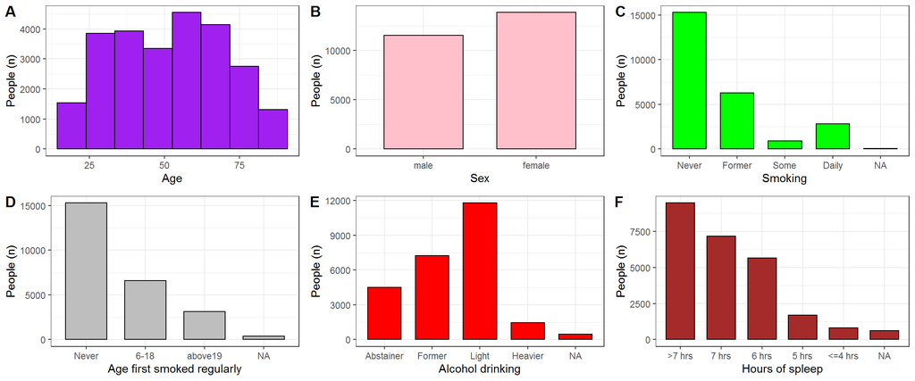

```r
#summary(XX0)
#ggpairs(XX0)
##plots
p1 <- ggplot(data = XX0, aes(x=age )) +
  geom_histogram(bins = 8, color = "black", fill = "purple") +
  labs(y = "People (n)", x = "Age")  +
  theme_bw()
p2 <- ggplot(data = XX0, aes(x = sex )) +
  geom_bar(color = "black", fill = "pink", width = 0.7) +
  labs(y = "People (n)", x = "Sex")  +
  theme_bw()
p3 <- ggplot(data = XX0, aes(x = smk)) +
  geom_bar(color="black", fill = "green", width = 0.7) +
  labs(y ="People (n)", x = "Smoking")  +
  theme_bw()
p4 <- ggplot(data = XX0, aes(x = age_smk)) +
  geom_bar(color ="black", fill = "grey", width=0.7) +
  labs(y = "People (n)", x = "Age first smoked regularly") +
  theme_bw()
p5 <- ggplot(data = XX0, aes(x = alc)) +
  geom_bar(color = "black", fill = "Red", width = 0.7) +
  labs(y = "People (n)", x = "Alcohol drinking")  +
  theme_bw()
p6 <- ggplot(data = XX0, aes(x = sleep)) +
  geom_bar(color = "black", fill = "brown", width = 0.7) +
  labs(y = "People (n)", x = "Hours of spleep")  +
  theme_bw()
p7 <- ggplot(data = XX0, aes(x = activ)) +
  geom_bar(color ="black", fill = "purple", width =0.7) +
  labs(y="People", x="Physical activity")  +
  theme_bw()
p8 <- ggplot(data = XX0, aes(x = BMI)) +
  geom_histogram(bins = 8, color = "blue", fill = "red") +
  labs(y = "People (n)", x = "BMI")  +
  theme_bw()
p9 <- ggplot(data = XX0, aes(x = fm_size)) +
  geom_bar(color="black", fill = "Brown", width=0.7) +
  labs(y="People (n)", x="Family size")  +
  theme_bw()
p10 <- ggplot(data = XX0, aes(x=race)) +
  geom_bar(color="black", fill = "lightblue", width=0.7) +
  labs(y="People", x="Race") +
  theme_bw()
p11 <- ggplot(data = XX0, aes(x = marriage)) +
  geom_bar(color = "black", fill = "pink", width = 0.7) +
  labs(y = "People (n)", x = "Marriage")  +
  theme_bw()
p12 <- ggplot(data = XX0, aes(x = par_stat)) +
  geom_bar(color = "black", fill = "blue", width = 0.7) +
  labs(y = "People (n)", x = "Children")  +
  theme_bw()

plot_grid(p1,p2,p3,p4,p5,p6,labels = "AUTO")
```

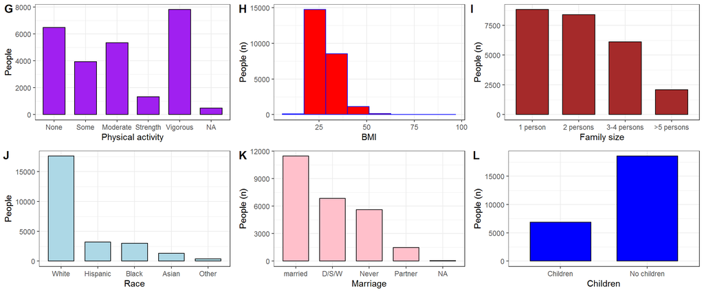

```r
plot_grid(p7,p8,p9,p10,p11,p12,labels = c("G","H","I","J","K","L","M"))
```

```r
# clearn memory
rm("Allxx", "chldrn", "XX0", "fm", "ps0", "ad", "ad0", "p1", "p2", "p3", "p4", "p5", "p6", "p7", "p8", "p9", "p10", "p11", "p12",
   "mis.ad", "mis.fm", "mis.ps", 'com.ad_ch', 'com.ad_fm', 'com.ad_pr', 'com.ch_ad', 'com.ch_fm', 'com.hs_fm', 'com.pr_ad', 'com.ps_fm', "prsn", "adlt", "fmly", "hshld", "NHIStables")
```

## 3.2. Exploration of Chronic Diseases vs. Alcohol and Smoking

Ratios of cases of selected disease are ploted against drinking and smoking, which are the 2 most interesting factors I would like to analyze.

```r
YY <- hlth %>%
  select(dis1, dis2, dis3, dis4, dis7,
         dis8,dis9, dis10, dis11, dis12,
         dis18, dis28,dis21, dis29, dis14, dis99)
#total number diseases by type
dis <- data.frame(sapply(YY, function(x) sum(as.numeric(x)==2, na.rm = TRUE)))
table(YY$dis99)
```

```
##
## No chronic liver disease    Chronic liver disease
##                    24636                      424
```

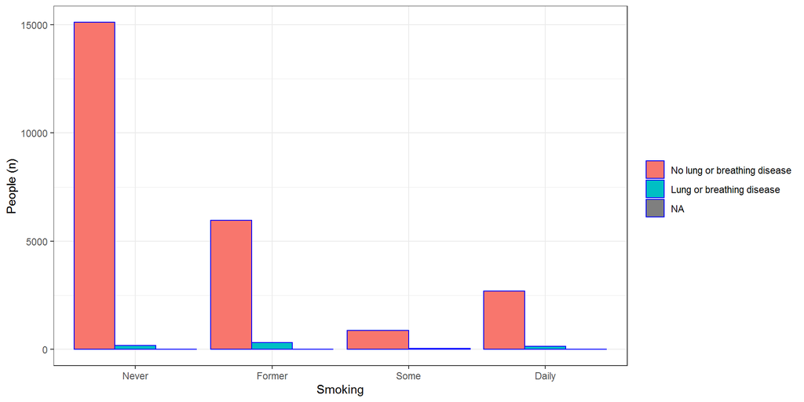

```r
dis$name <-  c("vision", "hearing", "arthritis","back or neck", "heart",
                "strock", "hypertension", "diabetes", "lung", "cancer",
                "weight", "circulation", "benign tumor", "alcohol/drug", "mental", "liver")
names(dis)[1] <- c("number.disease")
## try some contract
ggplot(data = hlth[!is.na(hlth$smk), ], aes(x = smk, fill = factor(dis11))) +
  geom_bar(position = "dodge", color="blue") +
  theme_bw()+
  labs(y="People (n)", x="Smoking")+
  theme(legend.title = element_blank())
```

> The above plot demonstrates that bar plots of absolute numbers of each disease categories are not suitable for comparison against the categories of other variables, Thus, bar plots of ratios will be applied.

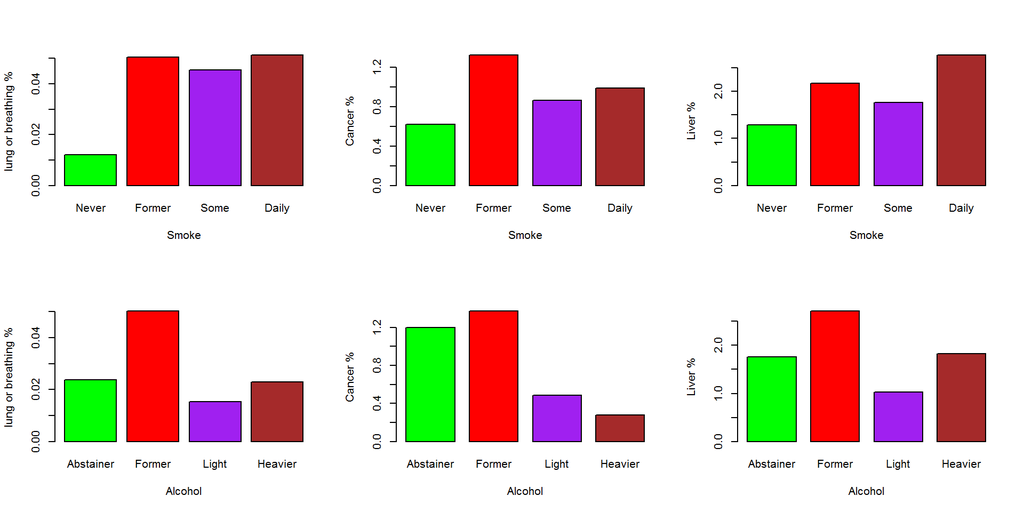

```r
# check ratio: smoke
par(mfrow=c(2,3))
tmt <- with(hlth[!is.na(hlth$smk), ], table(smk,dis11))
r=tmt[, 2]/(tmt[,1]+tmt[, 2])
barplot(r, xlab = "Smoke", ylab = "lung or breathing %", col = c("green", "red", "purple", "brown"))
tmt <- with(hlth[!is.na(hlth$smk), ], table(smk,dis12))
r=tmt[, 2]/(tmt[, 1] + tmt[, 2])*100
barplot(r, space = 0.3, xlab = "Smoke", ylab="Cancer %", col = c("green", "red","purple","brown"))
tmt <- with(hlth[!is.na(hlth$smk), ], table(smk, dis99))
r=tmt[, 2]/(tmt[, 1]+tmt[,2])*100
barplot(r, space =0.3,xlab = "Smoke", ylab="Liver %", col = c("green", "red","purple","brown"))
# alcohol
tmt <- with(hlth[!is.na(hlth$alc), ], table(alc,dis11))
r=tmt[, 2]/(tmt[, 1]+tmt[, 2])
barplot(r, xlab = "Alcohol", ylab="lung or breathing %", col = c("green", "red","purple","brown"))
tmt <- with(hlth[!is.na(hlth$alc), ], table(alc,dis12))
r=tmt[, 2]/(tmt[, 1]+tmt[, 2])*100
barplot(r, space =0.3, xlab = "Alcohol", ylab="Cancer %", col = c("green", "red", "purple", "brown"))
tmt <- with(hlth[!is.na(hlth$alc), ], table(alc,dis99))
r=tmt[,2]/(tmt[,1]+tmt[,2])*100
barplot(r, space =0.3, xlab = "Alcohol", ylab="Liver %", col = c("green", "red", "purple", "brown"))
```

> Smoking is bad to health, but drinking alcohol has mixed relationships with health.

## 3.3. Diseases and Parents

This section checked correlations between parent diseases and adult diseases. The diseases are linked using a parents flag in the adult data.

```r
## liver condition is not in the persons data
names(ps)
```

```
##  [1] "HHX"      "FMX"      "FPX"      "REGION"   "REGIONBR" "HISCODI3" "FSPOUS2"  "FMOTHER1" "FFATHER1"
## [10] "MOM_ED"   "DAD_ED"   "LADURA1"  "LADURA2"  "LADURA3"  "LADURA4"  "LADURA7"  "LADURA8"  "LADURA9"
## [19] "LADURA10" "LADURA11" "LADURA12" "LADURA18" "LADURA21" "LADURA28" "LADURA29" "LDURA14A" "LADURB1"
## [28] "LADURB2"  "LADURB3"  "LADURB4"  "LADURB7"  "LADURB8"  "LADURB9"  "LADURB10" "LADURB11" "LADURB12"
## [37] "LADURB18" "LADURB21" "LADURB28" "LADURB29" "LDURB14A" "PHSTAT"   "WRKLYR1"  "WRKFTALL"
```

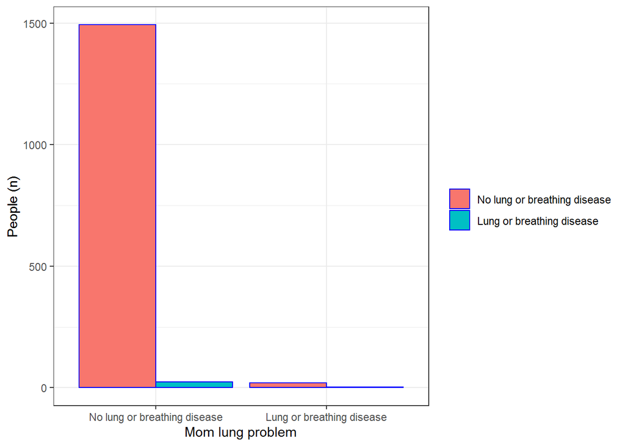

```r
mom <- ps %>%
  select(HHX, FMX, FPX,
         LADURB1,LADURB2,LADURB3, LADURB4, LADURB7, LADURB8,  LADURB9,LADURB10,
         LADURB11, LADURB12, LDURB14A, LADURB18, LADURB21, LADURB28, LADURB29) %>%
  mutate(FMOTHER1c=FPX,
         mdis1=factor(cut(LADURB1, breaks = c(-1.1, -0.1, 4), useNA='ifany'), labels = c("No vision disease", "Vision disease")),
         mdis2=factor(cut(LADURB2, breaks = c(-1.1, -0.1, 4), useNA='ifany'), labels = c("No hearing disease", "Hearing disease")),
         mdis3=factor(cut(LADURB3, breaks = c(-1.1, -0.1, 4), useNA='ifany'), labels = c("No arthritis disease", "Arthritis disease")),
         mdis4=factor(cut(LADURB4, breaks = c(-1.1, -0.1, 4), useNA='ifany'), labels = c("No back or neck disease", "Back or neck ")),
         mdis7=factor(cut(LADURB7, breaks = c(-1.1, -0.1, 4), useNA='ifany'), labels = c("No heart disease", "Heart disease")),

         mdis8=factor(cut(LADURB8, breaks = c(-1.1, -0.1, 4), useNA='ifany'), labels = c("No stroke disease", "Stroke")),
         mdis9=factor(cut(LADURB9, breaks = c(-1.1, -0.1, 4), useNA='ifany'), labels = c("No hypertension disease", "Hypertension disease")),
         mdis10=factor(cut(LADURB10, breaks = c(-1.1, -0.1, 4), useNA='ifany'), labels = c("No diabetes disease", "Diabetes disease")),
         mdis11=factor(cut(LADURB11, breaks = c(-1.1, -0.1, 4), useNA='ifany'), labels = c("No lung or breathing disease", "Lung or breathing disease")),
         mdis12=factor(cut(LADURB12, breaks = c(-1.1, -0.1, 4), useNA='ifany'), labels = c("No cancer disease", "Cancer disease")),

         mdis14=factor(cut(LDURB14A, breaks = c(-1.1, -0.1, 4), useNA='ifany'), labels = c("No mental retardation", "Mental retardation")),
         mdis18=factor(cut(LADURB18, breaks = c(-1.1, -0.1, 4), useNA='ifany'), labels = c("No weight problem", "Weight problem")),
         mdis21=factor(cut(LADURB21, breaks = c(-1.1, -0.1, 4), useNA='ifany'), labels = c("No circulation disease", "Circulation disease")),
         mdis28=factor(cut(LADURB28, breaks = c(-1.1, -0.1, 4), useNA='ifany'), labels = c("No benign tumor disease", "Benign tumor disease")),
         mdis29=factor(cut(LADURB29, breaks = c(-1.1, -0.1, 4), useNA='ifany'), labels = c("No alcohol/drug problem", "Alcohol/drug problem")),

   #      mdis99=fct_rev(factor(cut(LIVEV, breaks =c(0,1,2), useNA='ifany' ), labels=c("Chronic liver disease", "No chronic liver disease")))
            )
# Dad data, the same variable name pattern as mom's
dad <- ps %>%
  select(HHX, FMX, FPX,
         LADURB1,LADURB2,LADURB3, LADURB4, LADURB7, LADURB8,  LADURB9,LADURB10,
         LADURB11, LADURB12, LDURB14A, LADURB18, LADURB21, LADURB28, LADURB29) %>%
  mutate(FFATHER1c=FPX,
         ddis1=factor(cut(LADURB1, breaks = c(-1.1, -0.1, 4), useNA='ifany'), labels = c("No vision disease", "Vision disease")),
         ddis2=factor(cut(LADURB2, breaks = c(-1.1, -0.1, 4), useNA='ifany'), labels = c("No hearing disease", "Hearing disease")),
         ddis3=factor(cut(LADURB3, breaks = c(-1.1, -0.1, 4), useNA='ifany'), labels = c("No arthritis disease", "Arthritis disease")),
         ddis4=factor(cut(LADURB4, breaks = c(-1.1, -0.1, 4), useNA='ifany'), labels = c("No back or neck disease", "Back or neck ")),
         ddis7=factor(cut(LADURB7, breaks = c(-1.1, -0.1, 4), useNA='ifany'), labels = c("No heart disease", "Heart disease")),

         ddis8=factor(cut(LADURB8, breaks = c(-1.1, -0.1, 4), useNA='ifany'), labels = c("No stroke disease", "Stroke")),
         ddis9=factor(cut(LADURB9, breaks = c(-1.1, -0.1, 4), useNA='ifany'), labels = c("No hypertension disease", "Hypertension disease")),
         ddis10=factor(cut(LADURB10, breaks = c(-1.1, -0.1, 4), useNA='ifany'), labels = c("No diabetes disease", "Diabetes disease")),
         ddis11=factor(cut(LADURB11, breaks = c(-1.1, -0.1, 4), useNA='ifany'), labels = c("No lung or breathing disease", "Lung or breathing disease")),
         ddis12=factor(cut(LADURB12, breaks = c(-1.1, -0.1, 4), useNA='ifany'), labels = c("No cancer disease", "Cancer disease")),
         ddis14=factor(cut(LDURB14A, breaks = c(-1.1, -0.1, 4), useNA='ifany'), labels = c("No mental retardation", "Mental retardation")),
         ddis18=factor(cut(LADURB18, breaks = c(-1.1, -0.1, 4), useNA='ifany'), labels = c("No weight problem", "Weight problem")),
         ddis21=factor(cut(LADURB21, breaks = c(-1.1, -0.1, 4), useNA='ifany'), labels = c("No circulation disease", "Circulation disease")),
         ddis28=factor(cut(LADURB28, breaks = c(-1.1, -0.1, 4), useNA='ifany'), labels = c("No benign tumor disease", "Benign tumor disease")),
         ddis29=factor(cut(LADURB29, breaks = c(-1.1, -0.1, 4), useNA='ifany'), labels = c("No alcohol/drug problem", "Alcohol/drug problem")),
   #      mdis99=fct_rev(factor(cut(LIVEV, breaks =c(0,1,2), useNA='ifany' ), labels=c("Chronic liver disease", "No chronic liver disease")))
          )
# merge with hlth
hlth_par <- hlth %>%
  mutate(FFATHER1c=FFATHER1, FMOTHER1c=FMOTHER1) %>%
  left_join(mom, by = c("HHX","FMX", "FMOTHER1c")) %>%
  left_join(dad, by = c("HHX","FMX", "FFATHER1c"))

#table(hlth_par$dis11)
#table(hlth_par$dis11, hlth_par$mdis11)
#table(hlth_par$dis1, hlth_par$mdis1)
## check for relationship between adult and mom
ggplot(data = hlth_par[!is.na(hlth_par$mdis11), ], aes(x = dis11, fill = mdis11)) +
  geom_bar(position = "dodge", color="blue", na.rm = TRUE) +
  theme_bw()+
  labs(x="Mom lung problem", y="People (n)")+
  theme(legend.title = element_blank())
```

> The above plot suggests again the difficulty in displaying the diseases with absolute number count. So in this project most of the results will be shown in relative values or percents.

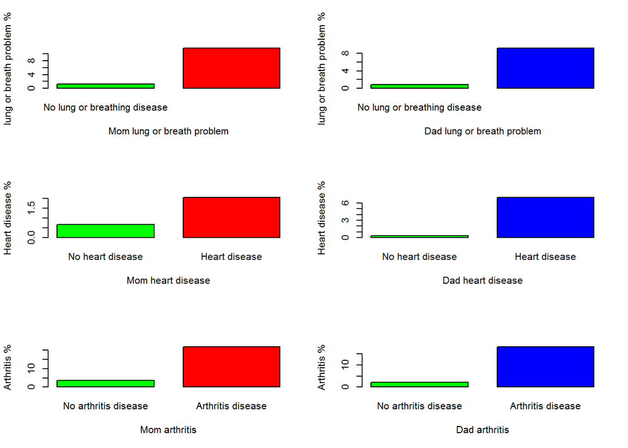

```r
# rate aldults and their parents
fig.dim=c(10, 7)
fig.width=9
par(mfrow=c(3,  2))
tmt <- with(hlth_par[!is.na(hlth_par$mdis11), ], table(mdis11,dis11))
r=tmt[,2]/(tmt[,1]+tmt[,2])*100
barplot(r, space =0.3,xlab = "Mom lung or breath problem", ylab="lung or breath problem %",  col=c("green","red"))
#dady
tmt <- with(hlth_par[!is.na(hlth_par$ddis11), ], table(ddis11,dis11))
r=tmt[,2]/(tmt[,1]+tmt[,2])*100
barplot(r, space =0.3,xlab = "Dad lung or breath problem", ylab="lung or breath problem %",  col=c("green","blue"))
# in this case the sample size is too small, 1 case would be too big
tmt <- with(hlth_par[!is.na(hlth_par$mdis7), ], table(mdis7,dis7))
r=tmt[,2]/(tmt[,1]+tmt[,2])*100
barplot(r, space =0.3,xlab = "Mom heart disease", ylab="Heart disease %", col=c("green","red"))
# in this case the sample size is too small, 1 case would be too big
tmt <- with(hlth_par[!is.na(hlth_par$ddis7), ], table(ddis7,dis7))
r=tmt[,2]/(tmt[,1]+tmt[,2])*100
barplot(r, space =0.3,xlab = "Dad heart disease", ylab="Heart disease %", col=c("green","blue"))
# in this case the sample size is too small, 1 case would be too big
tmt <- with(hlth_par[!is.na(hlth_par$mdis3), ], table(mdis3,dis3))
r=tmt[,2]/(tmt[,1]+tmt[,2])*100
barplot(r, space =0.3,xlab = "Mom arthritis", ylab="Arthritis %",  col=c("green","red"))
# in this case the sample size is too small, 1 case would be too big
tmt <- with(hlth_par[!is.na(hlth_par$ddis3), ], table(ddis3,dis3))
r=tmt[,2]/(tmt[,1]+tmt[,2])*100
barplot(r, space =0.3,xlab = "Dad arthritis", ylab="Arthritis %",  col=c("green","blue"))
```

```r
#names(hlth_par)
```

> Parents’ health is relevant to adults’ health.

# 4. Regional Variation

Maps of selected predictors and diseases are produced to represent regional variations

## 4.1. Regional Variation of Drinking and Smoking

Drinking and smoking ratios are displayed on the US regional map. A map function is created to map variables.

```r
#map
# assign a region for each state. Region definition is based on maps of the US Census Beaurau
state$STATE=as.integer(state$GEOID)
NorthEast <- c(9, 10, 11, 23, 24, 25, 33, 34, 36, 42, 44, 50)
MidWest <- c(17, 18, 19, 20, 26, 27, 29, 31, 38, 39, 46, 55)
South <- c(1, 5, 12, 13, 21, 22, 28, 37, 40, 45, 47, 48, 51, 54)
West <-  c(4, 6, 8, 16, 30, 32, 35, 41, 49, 53, 56)
#geos is only a object name for the geometric data
geos <- state[!(state$STATE %in% c(2, 15, 72)), ]
geos$REGION[geos$STATE %in% NorthEast] <- 1
geos$REGION[geos$STATE %in% MidWest] <- 2
geos$REGION[geos$STATE %in% South] <- 3
geos$REGION[geos$STATE %in% West] <- 4
#check data
#table(geos$REGION)
geos[geos$REGION==2,]
```

```
## Simple feature collection with 12 features and 7 fields
## geometry type:  MULTIPOLYGON
## dimension:      XY
## bbox:           xmin: -104.0577 ymin: 35.99568 xmax: -80.51869 ymax: 49.38436
## epsg (SRID):    4269
## proj4string:    +proj=longlat +datum=NAD83 +no_defs
## First 10 features:
##    GEOID         NAME   variable estimate moe                       geometry STATE REGION
## 14    17     Illinois B01003_001 12851684  NA MULTIPOLYGON (((-91.51297 4...    17      2
## 15    18      Indiana B01003_001  6589578  NA MULTIPOLYGON (((-88.09776 3...    18      2
## 16    19         Iowa B01003_001  3106589  NA MULTIPOLYGON (((-96.6397 42...    19      2
## 17    20       Kansas B01003_001  2898292  NA MULTIPOLYGON (((-102.0517 4...    20      2
## 23    26     Michigan B01003_001  9909600  NA MULTIPOLYGON (((-83.98756 4...    26      2
## 24    27    Minnesota B01003_001  5450868  NA MULTIPOLYGON (((-89.59206 4...    27      2
## 26    29     Missouri B01003_001  6059651  NA MULTIPOLYGON (((-95.77355 4...    29      2
## 28    31     Nebraska B01003_001  1881259  NA MULTIPOLYGON (((-104.0534 4...    31      2
## 35    38 North Dakota B01003_001   736162  NA MULTIPOLYGON (((-104.0487 4...    38      2
## 36    39         Ohio B01003_001 11586941  NA MULTIPOLYGON (((-82.73571 4...    39      2
```

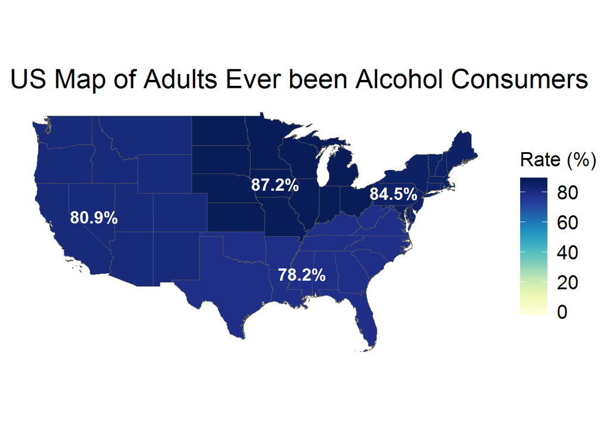

```r
#Percent of Abstainers by region
regionx <- hlth %>% filter(!is.na(alc)) %>% group_by(REGION, alc) %>% summarise(n= n())
tot <- regionx %>% group_by(REGION) %>% summarise(n= sum(n))
# Abst for alcohol abstainer
Abst <- left_join(regionx, tot, by = "REGION", suffix = c("_1", "_t")) %>%
  filter(alc=="Abstainer") %>%
  mutate( per = 100-n_1/n_t*100) %>%
  select(REGION, per)
#theme
my_theme <- function() {
  theme_minimal() +
  theme(axis.line = element_blank(),
        axis.text = element_blank(),
        axis.title = element_blank(),
        panel.grid = element_line(color = "white"),
        legend.key.size = unit(0.8, "cm"),
        legend.text = element_text(size = 16),
        legend.title = element_text(size = 16),
        plot.title = element_text(size = 22))
}
#coordinates of labels for Regions
coordinates = st_coordinates(st_point_on_surface(geos))
##Map function that will be used for all region maps
Rmap <- function(vrb, title,colors){
   # merge data
  map1 <- left_join( geos, vrb,by = "REGION")
  prev_min <-min(as.numeric(map1$per), na.rm = TRUE)
  prev_max <- max(as.numeric(map1$per), na.rm = TRUE)

  myPalette <- colorRampPalette(brewer.pal(9, colors))

   # Center of geometry
  map2 <- data.frame(map1,coordinates)
  map2$perc=as.character(paste0(round(map2$per,1),"%"))
  map2$lab=ifelse(map2$STATE %in% c(42, 19, 28,32), map2$perc,'')

  ggplot() +
    geom_sf(data=map1, lwd = 0, aes(fill = map1$per)) +
    my_theme() +
    ggtitle(title)+
    scale_fill_gradientn(name = "Rate (%)", colours = myPalette(50),
                         limit = range(0, prev_max))  +
    geom_text(data = map2, aes(x=X, y=Y, label=lab), size = 5, fontface = "bold",color="white")
}
# map for Alcohol
Rmap(Abst, "US Map of Adults Ever been Alcohol Consumers", "YlGnBu")
```

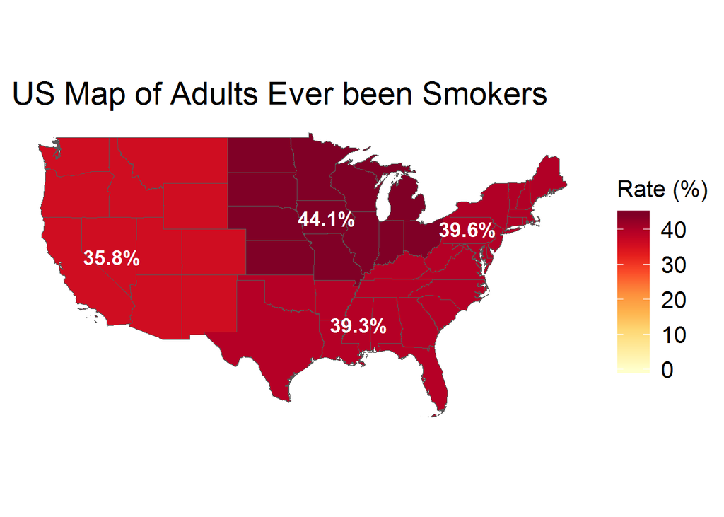

```r
#percent of Never smoke by region
regionx <- hlth %>% filter(!is.na(smk)) %>% group_by(REGION, smk) %>% summarise(n= n())
tot <- regionx %>% group_by(REGION) %>% summarise(n= sum(n))
# Abst is for "never smoking" here
nonsmk <- left_join(regionx, tot, by = "REGION", suffix = c("_1", "_t")) %>%
  filter(smk=="Never") %>%
  mutate( per=100-n_1/n_t*100) %>%
  select(REGION, per)
# map for Alcohol
Rmap(nonsmk, "US Map of Adults Ever been Smokers", "YlOrRd")
```

## 4.2. Regional Variabtion of Diseases

For those rarely occured diseases the regional level percentages of specific categorie are quite meaningful. This section of analysis displays some examples of veriations among the 4 regions. Maps in this section are based on continental state multipolygon vector geometry data from US Census Beaureu website. States in the same region are shown in the same color that indicate the percentage values of the region.

```r
par(mfrow=c(3,2))
#lung diseases %
regionx <- hlth %>% filter(!is.na(dis11)) %>% group_by(REGION, dis11) %>% summarise(n= n())
tot <- regionx %>% group_by(REGION) %>% summarise(n= sum(n))
Lung <- left_join(regionx, tot, by = "REGION", suffix = c("_1", "_t")) %>%
  filter(dis11=="Lung or breathing disease") %>%
  mutate( per=n_1/n_t*100) %>%
  select(REGION, per)
  class(Abst$REGION )
```

```
## [1] "integer"
```

```r
  class (geos$REGION)
```

```
## [1] "numeric"
```

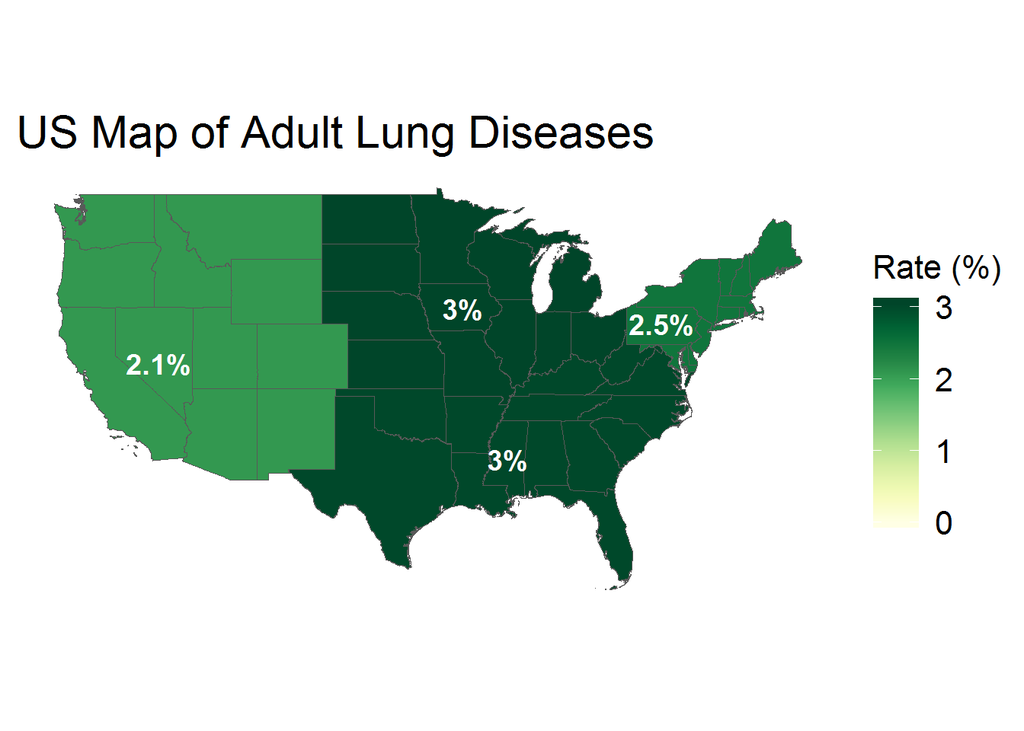

```r
  colors="Purples"
  title="Title"
Rmap(Lung,"US Map of Adult Lung Diseases", "YlGn")
```

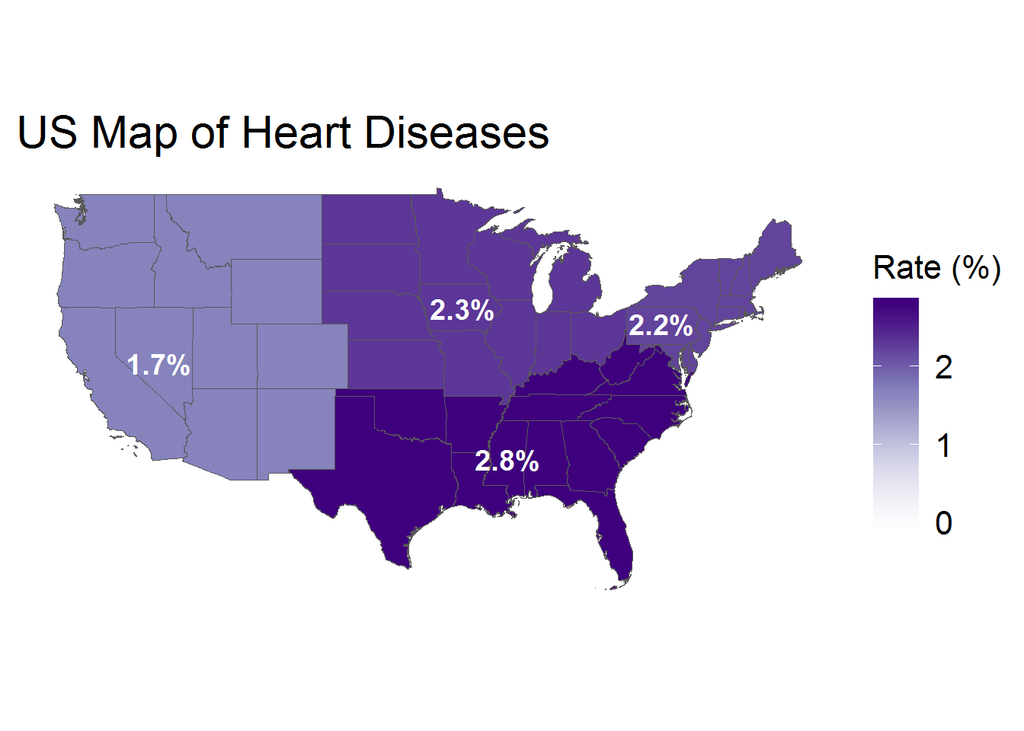

```r
#Heart diseases %
regionx <- hlth %>% filter(!is.na(dis7)) %>% group_by(REGION, dis7) %>% summarise(n= n())
tot <- regionx %>% group_by(REGION) %>% summarise(n= sum(n))
Heart <- left_join(regionx, tot, by = "REGION", suffix = c("_1", "_t")) %>%
  filter(dis7=="Heart disease") %>%
  mutate( per=n_1/n_t*100) %>%
  select(REGION, per)
Rmap(Heart,"US Map of Heart Diseases", "Purples")
```

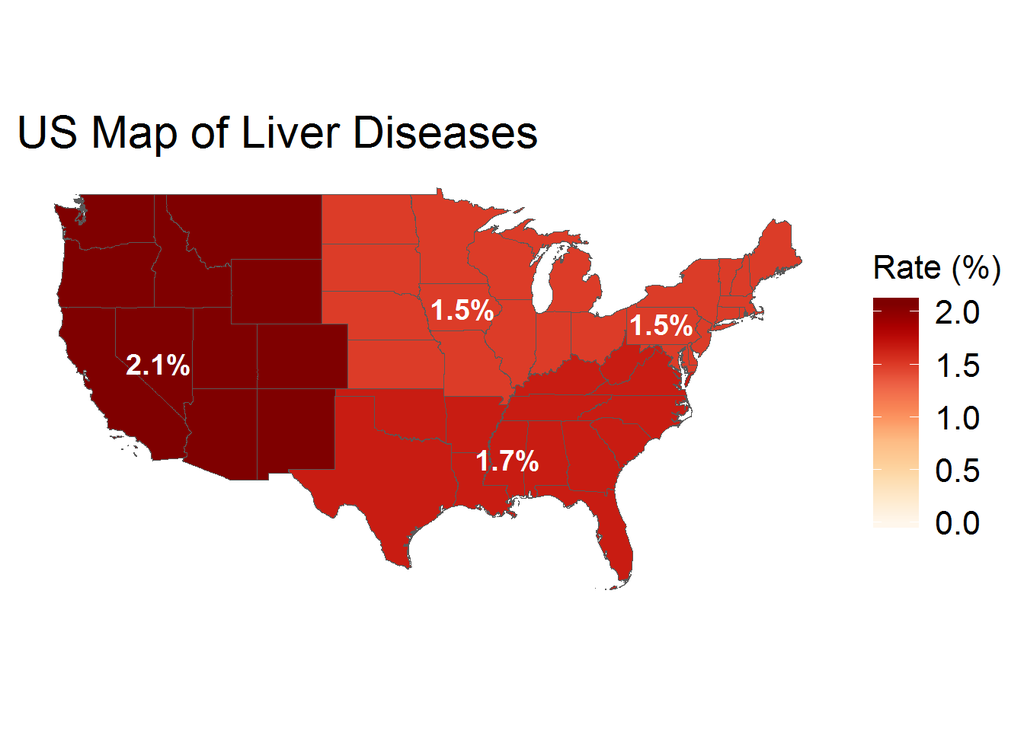

```r
#Liver %
regionx <- hlth %>% filter(!is.na(dis99)) %>% group_by(REGION, dis99) %>% summarise(n= n())
tot <- regionx %>% group_by(REGION) %>% summarise(n= sum(n))
Liver <- left_join(regionx, tot, by = "REGION", suffix = c("_1", "_t")) %>%
  filter(dis99=="Chronic liver disease") %>%
  mutate( per=n_1/n_t*100) %>%
  select(REGION, per)
Rmap(Liver, "US Map of Liver Diseases", "OrRd")
```

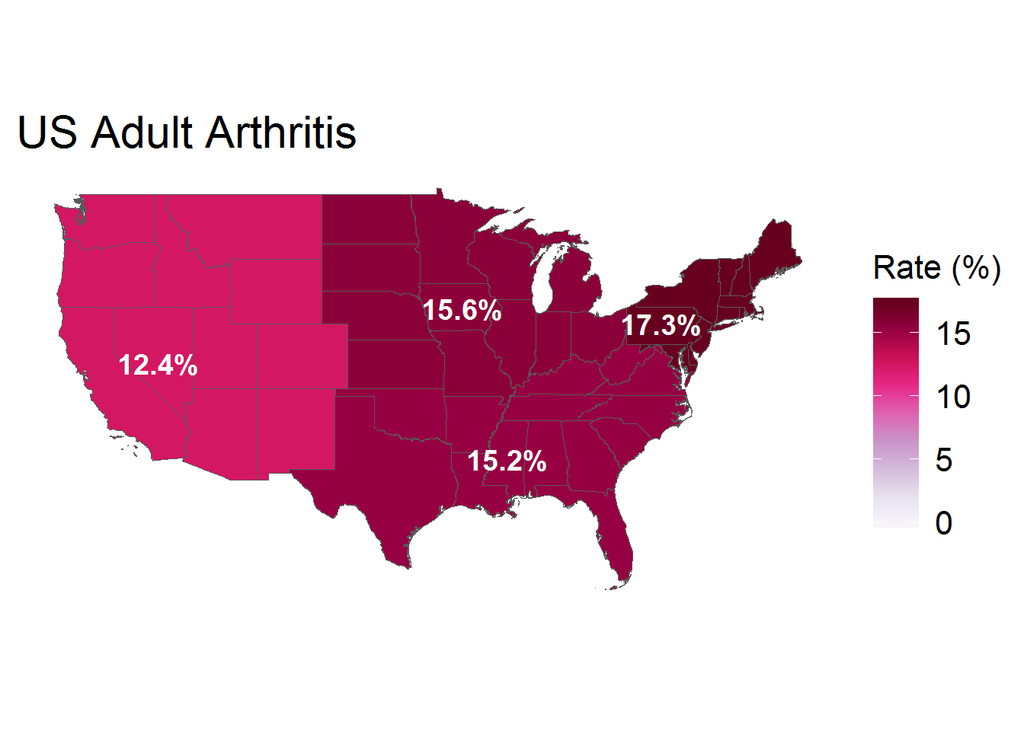

```r
#Arthritis diseases %
regionx <- hlth %>% filter(!is.na(dis3)) %>% group_by(REGION, dis3) %>% summarise(n= n())
tot <- regionx %>% group_by(REGION) %>% summarise(n= sum(n))
Arthritis <- left_join(regionx, tot, by = "REGION", suffix = c("_1", "_t")) %>%
  filter(dis3=="Arthritis disease") %>%
  mutate( per=n_1/n_t*100) %>%
  select(REGION, per)
Rmap(Arthritis, "US Adult Arthritis", "PuRd")
```

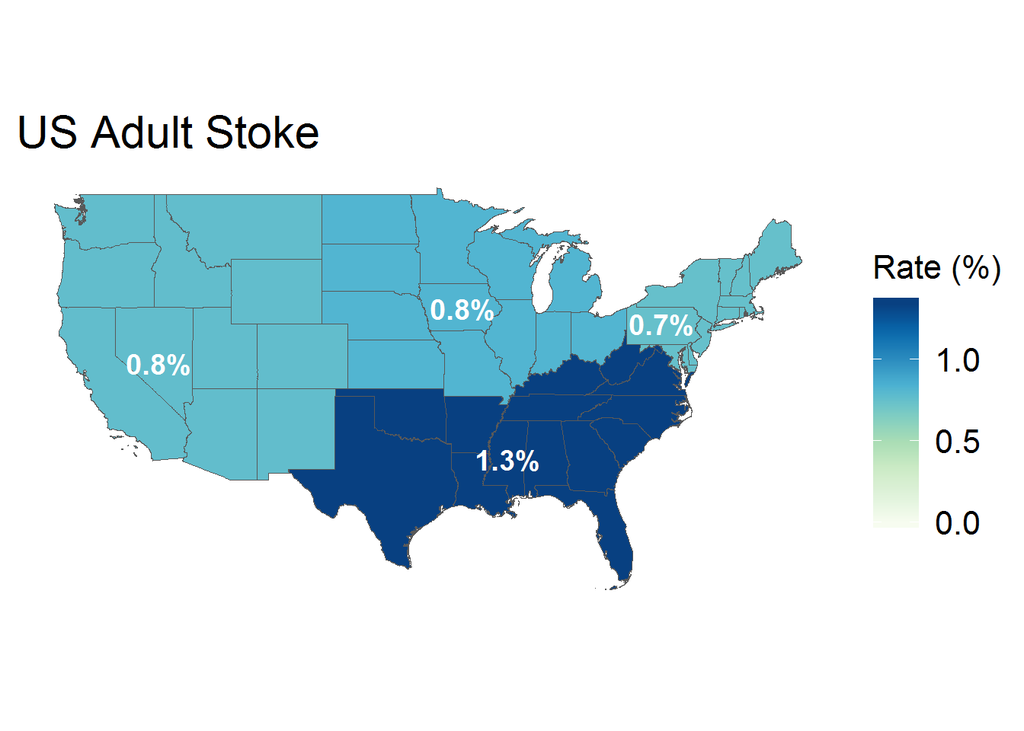

```r
#stroke %
regionx <- hlth %>% filter(!is.na(dis8)) %>% group_by(REGION, dis8) %>% summarise(n= n())
tot <- regionx %>% group_by(REGION) %>% summarise(n= sum(n))
stroke <- left_join(regionx, tot, by = "REGION", suffix = c("_1", "_t")) %>%
  filter(dis8=="Stroke") %>%
  mutate( per=n_1/n_t*100) %>%
  select(REGION, per)
Rmap(stroke,"US Adult Stoke", "GnBu")
```

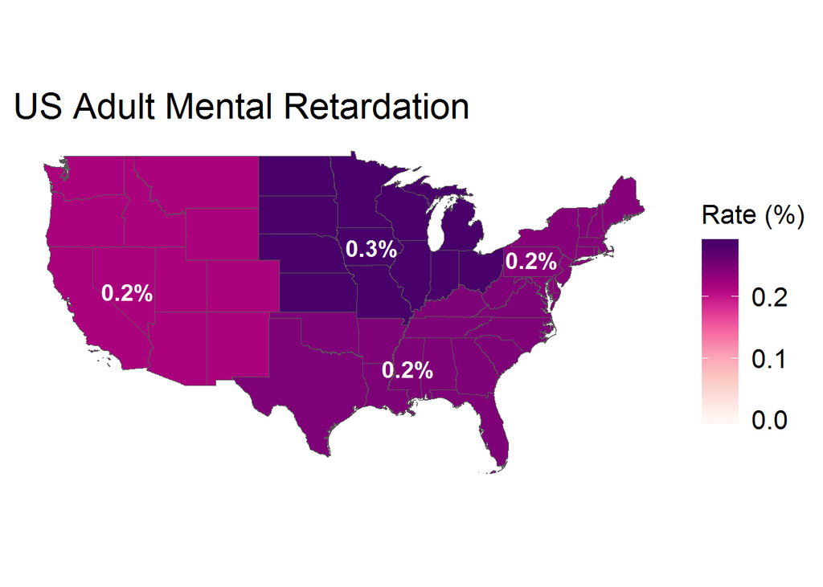

```r
#Mental retardation
regionx <- hlth %>% filter(!is.na(dis14)) %>% group_by(REGION, dis14) %>% summarise(n= n())
tot <- regionx %>% group_by(REGION) %>% summarise(n= sum(n))
Mental <- left_join(regionx, tot, by = "REGION", suffix = c("_1", "_t")) %>%
  filter(dis14=="Mental retardation") %>%
  mutate( per=n_1/n_t*100) %>%
  select(REGION, per)
Rmap(Mental,"US Adult Mental Retardation", "RdPu")
```

# 5. Modeling Relationships between Diseases and Predictors.

All the diseases have binary values and logistic models are intuitive methods. Only age and BMI are kept to be numeric variables. Factors are first transformed into binary variables before the estimation of models. Baseline categories are the ones that omitted in the estimation results.

## 5.1. Variables Significantly Correlated to Health

Variables/categories of variables that are significantly correlated to diseases are identified with logistic estiamtes.

```r
dis_Names <- c("Vision","Hearing", "Arthritis","Back_neck", "Heart",
              "Stroke","Hypertension", "Diabetes", "Lung_breath", "Cancer",
              "Mental", "Weight", "Circulation", "Benign_tumor","Alcohol_drug",
              "Chronic_liver")
# reset the XX incase order change
# age, BMI are numeric, others are factors
XX <- hlth %>%
  select(age, sex, race,  smk, alc, sleep, activ,
          fm_size, marriage, par_stat, BMI, region) ##HHX, FMX, FPX,age_smk,
# Reset the YY in case order change
YY <- hlth %>%
  select(dis1, dis2, dis3, dis4, dis7,
         dis8, dis9, dis10, dis11, dis12,
         dis14, dis18, dis21, dis28, dis29,
         dis99)
i=1
cef <- NA
sigName = NA
dstName = NA
sigcef <- NA
pval <- NA
for (i in 1:16) {
  Y=YY[,i]
  YXX <- data.frame(Y, XX)
  YXX <- YXX[complete.cases(YXX),]
  #dim(data.frame(Y, XX))
  dim(YXX)
  Xmat <- data.frame(model.matrix(~., data = YXX[, c(2:ncol(YXX))] ))
  dt <-  data.frame(y=YXX[,"Y"],Xmat)
  dt.glm <- glm( y ~ . , data =dt, family = binomial(logit))
  s <- summary(dt.glm)$coefficients[,4]
  c <- summary(dt.glm)$coefficients[s<0.05, "Estimate"]
  nam <- names(c)[2:length(c)]
  sigName[i] <- list(nam)   #significant var names
  sigcef[i] <- list(c)      #significant coefficients
  cef[i] <-  list(summary(dt.glm)$coefficients[, "Estimate"]) ## all estimate
  pval[i] <- list(s)
  }
#sigName
cefTab <- as.data.frame(cef)
pvalTab <- as.data.frame(pval)
sig <- as.data.frame(pval) < 0.05
sig=ifelse(sig==0, NA, sig)
sigTab <- cefTab*sig
names(sigTab)=names(YY)
sigTabf <- round(sigTab, 2)
print(sigTabf)
```

```
##                      dis1   dis2  dis3  dis4  dis7  dis8   dis9 dis10 dis11 dis12 dis14  dis18 dis21  dis28
## (Intercept)         -6.83 -10.21 -7.42 -4.32 -7.74 -7.42 -10.08 -9.43 -7.77 -6.15 -6.82 -10.68 -9.49 -11.38
## age                  0.04   0.06  0.06  0.02  0.05  0.04   0.05  0.05  0.03  0.03    NA   0.01  0.04     NA
## sexfemale              NA  -0.47  0.51  0.16 -0.45 -0.42  -0.26 -0.47    NA    NA -1.28     NA    NA   1.94
## raceHispanic         0.54     NA    NA -0.16    NA  0.47   0.89  1.05 -0.48    NA    NA     NA    NA     NA
## raceBlack            0.35     NA    NA    NA    NA  0.83   0.98  0.81    NA    NA    NA  -0.52    NA     NA
## raceAsian              NA     NA -0.63 -0.55    NA    NA   0.79  0.91 -0.87    NA    NA     NA    NA     NA
## raceOther            0.94     NA  0.50    NA  0.70    NA   1.02  1.37    NA    NA    NA     NA    NA     NA
## smkFormer              NA     NA  0.26  0.30  0.52  0.40   0.28  0.41  1.02  0.48    NA   0.37  0.37     NA
## smkSome                NA     NA  0.55  0.66  0.66    NA   0.52  0.57  1.38    NA    NA     NA    NA     NA
## smkDaily               NA     NA  0.58  0.63  0.80  0.74   0.55  0.78  1.30    NA    NA   0.37  0.86     NA
## alcFormer              NA     NA    NA  0.19    NA    NA     NA    NA  0.37    NA -1.27   0.47  0.50     NA
## alcLight            -0.94  -0.42 -0.12    NA -0.82 -0.73  -0.69 -0.94 -0.29 -0.55 -1.55     NA    NA     NA
## alcHeavier             NA     NA    NA    NA -1.23 -1.13     NA -0.86    NA -1.52 -2.30     NA    NA     NA
## sleep7.hrs             NA     NA    NA    NA -0.32 -0.58     NA    NA -0.25    NA -1.01     NA    NA     NA
## sleep6.hrs             NA     NA  0.29  0.37    NA    NA   0.26  0.25    NA    NA    NA   0.35    NA     NA
## sleep5.hrs           0.44     NA  0.56  0.72    NA    NA   0.59  0.55  0.48    NA    NA     NA    NA     NA
## sleep..4.hrs         0.88   1.01  0.92  1.15  0.77    NA   1.04  0.78  0.67    NA    NA     NA  0.90   1.68
## activSome           -0.45  -0.60    NA -0.13 -0.80 -0.69  -0.40 -0.55 -0.51 -0.89    NA     NA    NA     NA
## activModerate       -0.33  -0.50 -0.19    NA -0.67 -0.59  -0.78 -0.64 -0.52 -1.01    NA     NA -0.46     NA
## activStrength          NA     NA  0.23    NA    NA    NA  -0.43 -0.46    NA -0.67    NA     NA    NA     NA
## activVigorous       -0.65  -0.82 -0.45 -0.57 -1.28 -1.30  -0.99 -0.96 -1.27 -1.88 -1.52     NA -0.74     NA
## fm_size2.persons       NA     NA    NA    NA    NA    NA   0.43    NA    NA    NA    NA     NA  0.50     NA
## fm_size3.4.persons     NA   0.55    NA    NA    NA    NA   0.67    NA    NA    NA  1.09     NA    NA     NA
## fm_size.5.persons      NA   1.42    NA    NA    NA    NA   0.64    NA    NA    NA    NA     NA  1.34     NA
## marriageD.S.W        0.36   0.58  0.14  0.14  0.45  0.56   0.68    NA  0.57    NA    NA   0.49  0.62     NA
## marriageNever        0.47   0.55    NA -0.16    NA    NA   0.58    NA  0.51    NA  2.45     NA    NA     NA
## marriagePartner      0.52     NA    NA    NA    NA  0.84   0.50  0.65    NA    NA    NA     NA    NA     NA
## par_statNo.children    NA   0.95    NA    NA    NA    NA   0.69  0.45  0.55  0.93    NA     NA  0.74     NA
## BMI                  0.02   0.03  0.06  0.04  0.05    NA   0.07  0.08  0.03    NA    NA   0.16  0.04     NA
## regionMidwest          NA   0.43 -0.14  0.17    NA    NA     NA    NA    NA    NA    NA   0.41    NA     NA
## regionSouth            NA     NA -0.16    NA    NA    NA   0.35    NA    NA    NA    NA     NA    NA     NA
## regionWest             NA     NA -0.22  0.21    NA    NA     NA    NA    NA    NA    NA     NA    NA     NA
##                     dis29 dis99
## (Intercept)            NA -4.76
## age                    NA  0.01
## sexfemale              NA -0.26
## raceHispanic           NA    NA
## raceBlack              NA    NA
## raceAsian              NA    NA
```

[output cut: 11 more lines]

```
## activSome              NA -0.31
## activModerate          NA -0.43
## activStrength          NA    NA
## activVigorous          NA -0.65
## fm_size2.persons       NA    NA
## fm_size3.4.persons     NA -0.50
## fm_size.5.persons      NA    NA
## marriageD.S.W          NA    NA
## marriageNever          NA    NA
## marriagePartner        NA    NA
## par_statNo.children    NA -0.41
## BMI                    NA  0.02
## regionMidwest          NA    NA
## regionSouth            NA    NA
## regionWest             NA  0.33
```

> The above table contends all the significant coefficients whose p-values are less than 0.05. Those “NA” values in the table represent insignificant coefficients. The next section will display them in a heat map.

## 5.2. Heatmap of P-values

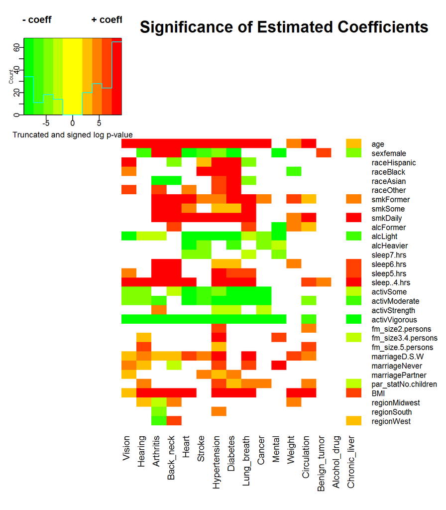

```r
# Obtain the signs of estimated coefficients, 1= positive, -1=negtative
HMsign <- cefTab
HMsign[cefTab>0] = 1
HMsign[cefTab<0] = -1
#log transformation
lps <- log(pvalTab)
# significance ones <0.05 are kept
lps[pvalTab>=0.05] = NaN
#add sign
pmat <- lps*HMsign*(-1)
X <- as.matrix(pmat[-1, ])
#Truncation for managing extremely small p-values for reasonable color scheme
Z <- X
Z[X > -log(0.0001)] = -log(0.0001)
Z[X <= log(0.0001)] = log(0.0001)
# add names of diseases for each model
colnames(Z) <- dis_Names
# mgp and mar are used to adjust position of key,
# color panel is defined for transision of colors from green to yellow to red
# margin to make room for labels on the margin
heatmap.2(Z, col = colorpanel(10,"green","yellow", "red"),  Rowv = FALSE, Colv = FALSE,  na.color = "white",
          margin=c(8,8), trace="none",
          main="                    Significance of Estimated Coefficients",
          dendrogram = "none", key.xlab="Truncated and signed log p-value",
          key.par = list(mgp=c(1.2, 0.3, 0), mar=c(2.5, 2.5, 4, 0)), key.title = "- coeff               + coeff")
```

> The heatmap was designed to display the significant correlations (by the standard of p-values <=0.05) between diseases in columns and predictors in rows. Green in the the above heatmap is used to indicate negatively correlated to diseases and thus positively correlated to health. Red is for positively correlated to diseases and thus negatively related to health. The color scheme shown in the color key is realized using a truncated log-transformed p-values and the sign of its corresponding coefficients. There are 4 steps to transform the p-values: (1). Log-transform the p-values from the estimation; (2). Remove insignificant ones by replacing cells with NaN when corresponding p-values >= 0.05; (3). Add the sign of the corresponding estimated coefficients; (4). Truncate large values by +log(0.0001) and -log(0.0001) so that colors display in a right range.